# DATA 550 - Lab 1 - Visualizing world health data

In this lab we will be using both R and Python, and for each question you will develop an answer both in `ggplot` and in `Altair`. Although the `%%R` cell magic makes it convenient for us to do this in the same notebook, I would still recommend that you use a separate Jupyter Notebook with a dedicated R kernel or RStudio to develop your R code. The reasons for this are that autocompletion works better there and the error messages are easier to understand. Once you have developed the code for a question you can paste it into the corresponding R cell here and make sure it runs and shows up in the exported HTML.

## Submission instructions

rubric={mechanics:2}

You receive marks for submitting your lab correctly, please follow these instructions:

- Create a GitHub Repo for your group.
  - Keep this organized, i.e. with a separate clearly marked folder for each assignment.
- [Click here to view a description of the rubrics used to grade the questions](https://github.com/UBC-MDS/public/tree/master/rubric)
- Push your `.ipynb` file to your GitHub repository for this lab.
- Include a clickable link to your GitHub repo for the lab just below this cell
  - It should look something like this https://github.ubc.ca/MDS-2025/DATA_550_labX_groupY.
- Upload a `.html` version of your assignment to Canvas.
  - Run all cells in your notebook to make sure there are no errors by doing `Kernel -> Restart Kernel and Run All Cells...`
  - Convert your notebook to .html format using `File -> Save and Export Notebook As -> HTML`
  - Submit and double check that your have submitted the correct file to Canvas

https://github.com/Manpreet702/DataViz_550.git

```python
# Run this cell to ensure that altair plots show up in the exported HTML
# and that the R cell magic works
import altair as alt

# Install vegafusion and vl-convert-python if not already installed
!pip install --quiet "vegafusion[embed]>=1.5.0" "vl-convert-python>=1.6.0"

# Save a vega-lite spec and a PNG blob for each plot in the notebook
alt.renderers.enable('mimetype')
# Handle large data sets by enabling VegaFusion
alt.data_transformers.enable('vegafusion')

# Load the R cell magic
%load_ext rpy2.ipython
```

```
The rpy2.ipython extension is already loaded. To reload it, use:
  %reload_ext rpy2.ipython
```

```python
import altair as alt
alt.renderers.enable('default')
```

```
RendererRegistry.enable('default')
```

# 1. Get motivated!

You have already worked with the Gapminder world health data set in the previous block and we will revisit an updated version of it in this lab. The Gapminder foundation strives to educate people about the public health status in countries all around the world and fight devastating misconceptions that hinder world development. This information is important both for our capacity to make considerate choices as individuals, and from an industry perspective in understanding where markets are emerging. In their research, Gapminder has discovered that most people don't really know what the world looks like today. Do you? [Take this 7-8 min quiz to find out](https://forms.gapminder.org/s3/test-2018).

This quiz is not easy, so don't worry if you get a low score. I took this quiz for the first time a few years back and I didn't do too well myself =) It is primarily meant to spark your curiosity to learn more about this lab's data set! When you are done, [please submit your score in this Google form](https://docs.google.com/forms/d/e/1FAIpQLSc2B0wlF-QWqAeJnHbu534WT-Twhpetk_4uUMM3LZvV0wv0mg/viewform?usp=sf_link). This is anonymous, I just want to explore if we can use the the distribution of scores for something interesting in class or future labs.

### Question 1.1

rubric={reasoning:1,writing:1}

To answer the first lab question [watch this 20 min video of Hans Rosling](https://www.youtube.com/watch?v=usdJgEwMinM) a public health professor at Karolinska Institute who founded Gapminder together with his son and his son's wife. Although the video is almost 15 years old, it is a formidable demonstration on how to present data in a way that engages your audience while conveying a strong, important message. (The original clip has over 3 million views, but I linked you one of better video quality).

Briefly describe (<=90 words) what you think is the most important message conveyed in the video and which data visualization you think was the most effective in getting this message across to the viewers.

The main message of Hans Rosling’s talk is that the world has improved much more than people think, and that the idea of a simple split between “rich” and “poor” countries is outdated. Most countries are moving toward better health and living standards over time. The most effective visualization is the animated bubble chart of income vs life expectancy, because seeing countries move across the plot over time makes the progress feel real, clear, and convincing rather than abstract statistics.

# 2. The Gapminder bubble chart

The "bubble chart" have become quite famous from their appearance in the Gapminder talks, and are widely used in other areas as well. Let's start by recreating a simple version of this chart ourselves!

There will be some data wrangling involved in this lab, and since 531 is primarily about visualization and this is the first lab, I will give you some hints for most data wrangling parts of this lab. Often I will link documentation or StackOverflow, so that you get practice finding information on these sources, and sometimes you will need to search them yourself if I haven't included a link.

To make this more interesting, I have compiled a more recent version of the Gapminder dataset, which contains values up until 2018 for most of the features. We will not use all the columns in the data set, but here is a description of what they contain that you can refer back to throughout the lab.

| Column | Description |
| --- | --- |
| country | Country name |
| year | Year of observation |
| population | Population in the country at each year |
| region | Continent the country belongs to |
| sub_region | Sub-region the country belongs to |
| income_group | Income group [as specified by the world bank in 2018](https://datahelpdesk.worldbank.org/knowledgebase/articles/378833-how-are-the-income-group-thresholds-determined) |
| life_expectancy | The mean number of years a newborn would live if mortality patterns remained constant |
| income | GDP per capita (in USD) adjusted for differences in purchasing power |
| children_per_woman | Average number of children born per woman |
| child_mortality | Deaths of children under 5 years of age per 1000 live births |
| pop_density | Average number of people per km<sup>2</sup> |
| co2_per_capita | CO2 emissions from fossil fuels (tonnes per capita) |
| years_in_school_men | Mean number of years in primary, secondary, and tertiary school for 25-36 years old men |
| years_in_school_women | Mean number of years in primary, secondary, and tertiary school for 25-36 years old women |

### Question 2.1

rubric={accuracy:1,quality:1,viz:2}

#### Python

1. I have uploaded the [2018 Gapminder data at this URL.](https://raw.githubusercontent.com/UofTCoders/workshops-dc-py/master/data/processed/world-data-gapminder.csv) Use `read_csv` from `pandas` to load the data directly from the URL and assign it a suitable variable name. Set the `parse_dates` parameter to `['year']` to ensure that Altair recognizes this columns as time data.
2. Now let’s create a similar bubble chart to what you saw in the video:
   - Filter the dataframe to only keep observations from a single year, 1962. You can create a new data frame variable or perform the filtering directly as you pass the data to Altair. Dates can be matched as strings when filtering.
   - Use a circle mark to recreate the appearance of the plot in the video.
   - Encode the proper variables so that children per woman is on the x-axis, life expectancy on the y-axis, and so that the circles’ color corresponds to their region, and the size reflects the population.

Don't worry about getting axis labels and sizes to be exactly like in the video, we will return to this code later in the lab to customize it.

```python
import pandas as pd
import altair as alt
data=pd.read_csv("https://raw.githubusercontent.com/UofTCoders/workshops-dc-py/master/data/processed/world-data-gapminder.csv")

filter_year=data['year']==1962
data_ByYear=data[filter_year]
# print(data_ByYear.head())
alt.Chart(data_ByYear).mark_circle().encode(
y = 'life_expectancy',
x = 'children_per_woman',
size='population',
color='region'
)
```

[interactive chart not shown]

```python
data.info()
```

```
<class 'pandas.core.frame.DataFrame'>
RangeIndex: 38982 entries, 0 to 38981
Data columns (total 14 columns):
 #   Column                 Non-Null Count  Dtype
---  ------                 --------------  -----
 0   country                38982 non-null  object
 1   year                   38982 non-null  int64
 2   population             38982 non-null  int64
 3   region                 38982 non-null  object
 4   sub_region             38982 non-null  object
 5   income_group           38982 non-null  object
 6   life_expectancy        38982 non-null  float64
 7   income                 38982 non-null  int64
 8   children_per_woman     38982 non-null  float64
 9   child_mortality        38980 non-null  float64
 10  pop_density            12282 non-null  float64
 11  co2_per_capita         16285 non-null  float64
 12  years_in_school_men    8188 non-null   float64
 13  years_in_school_women  8188 non-null   float64
dtypes: float64(7), int64(3), object(4)
memory usage: 4.2+ MB
```

### Question 2.2

rubric={accuracy:1,quality:1,viz:2}

#### R

1. I have uploaded the [2018 Gapminder data at this URL and assign it a suitable variable name.](https://raw.githubusercontent.com/UofTCoders/workshops-dc-py/master/data/processed/world-data-gapminder.csv) Use `read_csv` from `readr` to load the data directly from the URL.
2. Now let’s create a similar bubble chart to what you saw in the video:
   - Filter the dataframe to only keep observations from a single year, 1962. You can create a new data frame variable or (preferably) perform the filtering directly and pipe it to ggplot. Dates can be matched as strings when filtering.
   - Use a point geom to recreate the appearance of the plot in the video.
   - Encode the proper variables so that children per woman is on the x-axis, life expectancy on the y-axis, and so that the circles’ color corresponds to their region, and the size reflects the population.

Don't worry about getting axis labels and sizes to be exactly like in the video, we will return to this code later in the lab to customize it.

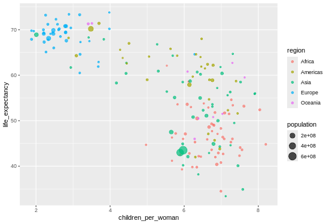

```python
%%R -w 550 -h 375
library(readr)
library(dplyr)
library(ggplot2)

# Load 2018 Gapminder-style data directly from the URL
gapminder_df <- read_csv("https://raw.githubusercontent.com/UofTCoders/workshops-dc-py/master/data/processed/world-data-gapminder.csv")

# Bubble chart for a single year (1962)
gapminder_df %>%
  filter(year == "1962") %>%
  ggplot(aes(
    x = children_per_woman,
    y = life_expectancy,
    color = region,
    size = population
  )) +
  geom_point(alpha = 0.7)
```